# Is the Male Tester Null Only for Yield, or Genome-Wide? A Trait-by-Trait Refit

Refitting the line × tester model on every phenotype in `data/multilocation.csv` and inspecting `isSingular()` and the male (tester) effect per trait

Author

Fausto Rodriguez Zapata

Published

June 29, 2026

**Source code & data:** https://github.com/faustovrz/gcamoz · **Companion note:** `male_gca_singularity_and_variance_routing.html`

# 1 The question this notebook settles

The yield model in `multilocation_alpha_lattice.html` gives a **zero male (tester) GCA** and `isSingular() == TRUE`. The [companion note](https://faustovrz.github.io/gcamoz/male_gca_singularity_and_variance_routing.html) argues this has a *germplasm* cause: the seven IIAM testers (donors **EN17, EN20, EN21, EN25, EN31, EN32, EN64** — the NCDII MOZL3/5/6/7/8/9/10 lines) were **double-ascertained** (an already-narrow CIMMYT/IIAM elite pool — CIMMYT ESA mean genetic distance ≈ 0.29, four lines dominating 29–58 % of hybrids; Masuka et al. 2017 — then **truncation-selected on yield** under phosphorus sufficiency), so they behave for combining-ability purposes as *“essentially the same male.”*

The open question (companion §3.3, §3.5) is **how far that “same male” claim reaches**:

| Mechanism | What it compresses | Male GCA zero for… |
| --- | --- | --- |
| **A. Ascertainment / truncation on yield** | among-tester variance for **yield and yield-correlated traits** | yield (and its correlates) only |
| **B. Narrow base / near-identity-by-descent** | among-tester variance for **every trait** | **all** traits |

Your extrapolation — *“if the top seven are essentially the same line, the zero holds for all phenotypes”* — requires **Mechanism B**. The decisive, falsifiable test is to **refit the identical model on every measured trait** and read off, per trait:

1. `isSingular()` of the mixed model, and the REML **male GCA variance** (does it pin to 0?);
2. a boundary-corrected **REML likelihood-ratio test** of σ²_male — dropping `(1|male)` while keeping `(1|male:env)`, so the tester effect is tested against the correct male×environment stratum (do the testers differ at all for this trait?).

**Reading:** male null *only* for yield → **Mechanism A** (the zero is a yield-selection artifact and does **not** generalize). Male null *across essentially all* traits → **Mechanism B** (the testers really are interchangeable genome-wide, and the extrapolation stands).

```r
library(tidyverse)
library(lubridate)
library(lme4)      # provides isSingular()
library(knitr)
library(kableExtra)
```

# 2 Data, field layout, and derived flowering traits

We reuse the exact data-preparation pipeline of the yield notebook — same factor coding, same recovery of field row/column from the 5 × 10 serpentine planting order — but we now carry **all** plot-level phenotypes, not just yield. The `NAMULONGUE` check (`GEN = 0`) is held out of the line × tester decomposition.

```r
raw_data <- read_csv("data/multilocation.csv", show_col_types = FALSE) %>%
  mutate(
    file_order = row_number(),                          # as-entered plot order
    ENV    = factor(env),
    REP    = factor(rep, levels = c("I", "II", "III")),
    GEN    = factor(gen, levels = as.character(0:49)),
    Female = factor(female,
                    levels = c("Check",
                               "CML364", "CML366", "CML434", "CML435",
                               "CML439", "CML530", "CML532")),
    # Males carry their IIAM donor IDs (NCDII MOZL3/5/6/7/8/9/10 = EN17/20/21/25/31/32/64).
    Male   = factor(male,
                    levels = c("Check",
                               "EN17", "EN20", "EN21", "EN25",
                               "EN31", "EN32", "EN64")),
    planting_date = as.Date(planting_date)
  )

# Field coordinates from the serpentine planting order (5 columns x 10 rows). ENTRY is the
# serpentine planting order, and it increases monotonically down the file within every
# ENV x REP block — so the file row order *is* the ENTRY order. We index plot_order by the
# file order rather than the `entry` column itself because two reps have damaged entries
# (CHOKWE STS III: 14 blanks + numbers that duplicate rep II's range; NHACOONGO II: 1
# blank) on which `row_number(entry)` would misplace plots. The physical row sequence is
# intact, so this recovers the exact serpentine layout. (Flag for Stelio to fix at source.)
field <- raw_data %>%
  group_by(ENV, REP) %>%
  arrange(file_order, .by_group = TRUE) %>%
  mutate(
    plot_order = row_number(),
    field_row  = ceiling(plot_order / 5),
    pos_in_row = ((plot_order - 1) %% 5) + 1,
    field_col  = if_else(field_row %% 2 == 1, pos_in_row, 6L - pos_in_row)
  ) %>%
  ungroup()
```

## 2.1 Flowering dates → days from planting

Stelio’s updated file now carries a **single planting date per location**, so we score flowering time as **days from planting** — the agronomically standard scale — instead of the day-of-year proxy the earlier version had to use:

- **DTS** (days to silking) = `silking_date` (female flowering / silk) − planting date.
- **DTA** (days to anthesis) = `anthesis_date` (male flowering / pollen shed) − planting date.
- **ASI** (anthesis–silking interval) = DTS − DTA, a within-plot difference that is **independent of planting date** regardless.

Because `env` is a **fixed** effect in every model below, the per-location planting date is absorbed by the environment means, so the *among-tester* GCA/SCA estimates are clean. The `silking_date`, `anthesis_date` and `planting_date` columns are stored as proper `yyyy-mm-dd` dates in `data/multilocation.csv` (the raw file mixed `dd/mm` strings and Excel date serials; these were parsed into dates during data cleaning), so here we simply take the day difference.

```r
field <- field %>%
  mutate(
    DTS = as.integer(silking_date  - planting_date),
    DTA = as.integer(anthesis_date - planting_date),
    ASI = DTS - DTA
  )

# Confirm every flowering date differenced to a day count (no missing dates).
parse_check <- tibble(
  trait      = c("DTS (silking)", "DTA (anthesis)"),
  n_missing  = c(sum(is.na(field$DTS)), sum(is.na(field$DTA)))
)
kable(parse_check, caption = "Flowering-date check (days from planting) — missing values should be 0") %>%
  kable_styling(bootstrap_options = c("striped", "hover", "condensed"), full_width = FALSE)
```

Flowering-date check (days from planting) — missing values should be 0

| trait | n_missing |
| --- | --- |
| DTS (silking) | 0 |
| DTA (anthesis) | 0 |

## 2.2 Hybrids-only analysis frame and the trait dictionary

```r
hybrids <- field %>%
  filter(GEN != "0") %>%
  transmute(
    env    = droplevels(ENV),
    rep    = REP,
    row    = factor(field_row, levels = 1:10),
    col    = factor(field_col, levels = 1:5),
    female = droplevels(Female),
    male   = droplevels(Male),
    cross  = factor(hybrid),
    # --- traits, carried by their publication abbreviations (see dictionary below) ---
    GY, GYPP, PUE, RSR, RYE, HI, NP, EW, GW, PH, SD, RW, DM, DTS, DTA, ASI
  )
```

Trait names everywhere below are the **publication abbreviations**; the metadata table maps each to its full name and unit. It is read from `data/multilocation_dictionary.csv`, the single source of truth for the column dictionary. The sweep covers **all sixteen plot-level phenotypes**, including the efficiency/index ratios (PUE phosphorus-use efficiency, RSR root:shoot, RYE relative yield efficiency, HI harvest index).

```r
# Phenotypes carried into the model (order = display order).
traits <- c("GY", "GYPP", "PUE", "RSR", "RYE", "HI", "NP", "EW", "GW", "PH", "SD", "RW", "DM",
            "DTS", "DTA", "ASI")

dict <- read_csv("data/multilocation_dictionary.csv", show_col_types = FALSE)
trait_units <- dict %>%
  filter(variable %in% traits) %>%
  mutate(variable = factor(variable, levels = traits)) %>%
  arrange(variable) %>%
  transmute(trait = as.character(variable), name, unit)

kable(trait_units %>% transmute(Abbrev = trait, Trait = name, Unit = unit),
      caption = "Trait dictionary — swept phenotypes, publication abbreviations and units (full metadata in `data/multilocation_dictionary.csv`).") %>%
  kable_styling(bootstrap_options = c("striped", "hover", "condensed"), full_width = FALSE)
```

Trait dictionary — swept phenotypes, publication abbreviations and units (full metadata in `data/multilocation_dictionary.csv`).

| Abbrev | Trait | Unit |
| --- | --- | --- |
| GY | Grain yield | t/ha |
| GYPP | Grain yield per plant | g |
| PUE | Phosphorus-use efficiency | g/g |
| RSR | Root:shoot ratio | g/g |
| RYE | Relative yield efficiency | g/g |
| HI | Harvest index | g/g |
| NP | Number of plants per plot (stand) | count |
| EW | Ear weight | g/plot |
| GW | Grain weight | g/plot |
| PH | Plant height | cm |
| SD | Stem (culm) diameter | cm |
| RW | Root weight | g/plot |
| DM | Dry matter mass (stover biomass) | g/plot |
| DTS | Days to silking | days |
| DTA | Days to anthesis | days |
| ASI | Anthesis-silking interval | days |

# 3 Data-quality screen

We screen every trait for gross data-entry errors **before** fitting anything, with a rule fixed in advance: for each trait, fit a saturated fixed-effects model and flag any plot whose **studentized residual exceeds 4** as a candidate error. Flagged plots are **excluded from that trait’s analysis** and listed here for Stelio to verify against the field books. Every result in this notebook is computed on the **screened** data.

```r
# Saturated fixed-effects model, used ONLY to flag gross errors (never for the
# signal test). |studentized residual| > 4  =>  candidate data-entry error.
screen_form <- y ~ env + env:rep + female + male + cross

flag_keep <- function(d) {                 # TRUE = keep, FALSE = flagged outlier
  r <- rstudent(lm(screen_form, data = d))
  is.na(r) | abs(r) <= 4
}
```

```r
outliers <- map_dfr(trait_units$trait, function(nm) {
  d <- hybrids %>% mutate(y = .data[[nm]]) %>% filter(!is.na(y))
  r <- rstudent(lm(screen_form, data = d))
  d %>% mutate(rstud = r) %>%
    filter(abs(rstud) > 4) %>%
    transmute(trait = nm, env, rep, female, male,
              value = round(y, 2), studentized_resid = round(rstud, 1))
}) %>% arrange(desc(abs(studentized_resid)))

kable(outliers, caption = "Flagged plots (|studentized residual| > 4), excluded per trait — candidate data-entry errors to verify against the field books.") %>%
  kable_styling(bootstrap_options = c("striped", "hover", "condensed"))
```

Flagged plots (|studentized residual| > 4), excluded per trait — candidate data-entry errors to verify against the field books.

| trait | env | rep | female | male | value | studentized_resid |
| --- | --- | --- | --- | --- | --- | --- |
| DTA | SUSSUNDENGA STS | I | CML366 | EN25 | 105.00 | 7.0 |
| DTS | SUSSUNDENGA STS | I | CML366 | EN25 | 108.00 | 6.7 |
| DM | CHOKWE STS | II | CML366 | EN25 | 665.28 | 6.3 |
| SD | NHACOONGO STS | III | CML530 | EN20 | 1.20 | -5.3 |
| DTA | SUSSUNDENGA STS | II | CML532 | EN25 | 98.00 | 5.1 |
| SD | CHOKWE STS | I | CML364 | EN20 | 1.52 | -4.9 |
| PUE | NHACOONGO STS | III | CML530 | EN25 | 1066.00 | 4.4 |
| DTS | SUSSUNDENGA STS | II | CML532 | EN25 | 99.00 | 4.4 |
| RYE | MANIQUENIQ OPT | I | CML435 | EN64 | 17.01 | 4.3 |
| PH | NHACOONGO STS | II | CML439 | EN21 | 213.00 | 4.2 |
| RSR | CHOKWE STS | II | CML364 | EN32 | 0.27 | 4.1 |
| NP | NHACOONGO STS | I | CML532 | EN17 | 3.00 | -4.1 |
| DTA | SUSSUNDENGA STS | II | CML364 | EN64 | 93.00 | 4.1 |
| DTA | SUSSUNDENGA STS | II | CML434 | EN32 | 93.00 | 4.1 |
| DTS | SUSSUNDENGA STS | II | CML364 | EN64 | 96.00 | 4.0 |

A second, physical check: a maize **ear weight** must be at least its **grain weight** (ear = grain + cob + husk). Plots that violate this are mis-entered.

```r
ear_lt_grain <- hybrids %>%
  mutate(ear = EW, grain = GW, ratio = round(ear / grain, 2)) %>%
  filter(ear < grain) %>%
  transmute(env, rep, female, male, ear, grain, ratio) %>%
  arrange(ratio)

cat(sprintf("Plots where ear weight < grain weight (impossible): %d of %d\n",
            nrow(ear_lt_grain), nrow(hybrids)))
```

```
Plots where ear weight < grain weight (impossible): 0 of 735
```

```r
kable(head(ear_lt_grain, 8),
      caption = "Impossible ear < grain plots (head) — ear or grain weight mis-entered") %>%
  kable_styling(bootstrap_options = c("striped", "hover", "condensed"), full_width = FALSE)
```

Impossible ear < grain plots (head) — ear or grain weight mis-entered

[output not shown]

# 4 The model and the test

On the **screened** data we fit the same mixed model as the yield notebook, with `lme4::lmer` (so `isSingular()` is available). The tester signal is judged by a **boundary-corrected REML likelihood-ratio test** of σ²_male: drop `(1 | male)` while **keeping** `(1 | male:env)`, so the tester *main* effect (GCA) is tested against its **male×environment** stratum — the correct yardstick for a GCA in a multi-environment trial. Testing a GCA against plot error is anticonservative, because each tester mean averages over hundreds of plots, so almost any spread clears that bar. Under the null σ²_male sits on the parameter boundary, so the LRT statistic follows a half-half mixture of chi-square(0) and chi-square(1) and the naive p is halved; **`p = 0.5` is the no-evidence floor.**

```r
# Random terms listed explicitly, so one can be dropped cleanly for the LRT.
rand_terms <- c("(1 | female)", "(1 | male)", "(1 | cross)",
                "(1 | female:env)", "(1 | male:env)", "(1 | cross:env)",
                "(1 | env:rep)", "(1 | env:rep:row)", "(1 | env:rep:col)")

build_form <- function(drop = character()) {
  as.formula(paste("y ~ env +", paste(setdiff(rand_terms, drop), collapse = " + ")))
}
mix_form <- build_form()
```

```r
fit_mm <- function(form, dat) suppressMessages(suppressWarnings(
  lmer(form, data = dat, REML = TRUE,
       control = lmerControl(check.conv.singular = "ignore",
                             optimizer = "bobyqa", optCtrl = list(maxfun = 2e5)))))

# Boundary-corrected REML LRT dropping (1|term) while keeping every other term
# (so (1|male) is tested ABOVE (1|male:env), the right GCA stratum). Under H0 the
# statistic ~ 0.5·χ²₀ + 0.5·χ²₁, so the one-sided p halves the naive χ²₁ p.
# Reduced model is refit directly with explicit data — no update().
lrt_vc <- function(full_fit, dat, term) {
  red  <- fit_mm(build_form(drop = paste0("(1 | ", term, ")")), dat)
  stat <- max(0, 2 * (as.numeric(logLik(full_fit)) - as.numeric(logLik(red))))
  min(0.5 * pchisq(stat, df = 1, lower.tail = FALSE), 1)
}

fit_one <- function(trait_name, data) {
  d_all <- data %>% mutate(y = .data[[trait_name]]) %>% filter(!is.na(y))
  keep  <- flag_keep(d_all)
  d     <- d_all[keep, ]                       # screened data = the analysis set

  fit <- fit_mm(mix_form, d)                   # PRIMARY model, on screened data
  vc  <- as.data.frame(VarCorr(fit))
  gv  <- function(g) { v <- vc$vcov[vc$grp == g]; if (length(v)) v else 0 }
  v_female <- gv("female"); v_male <- gv("male"); v_cross <- gv("cross")
  v_gen    <- v_female + v_male + v_cross

  p_male   <- lrt_vc(fit, d, "male")
  p_female <- lrt_vc(fit, d, "female")

  tibble(
    trait          = trait_name,
    singular       = isSingular(fit),
    sigma2_female  = v_female,
    sigma2_male    = v_male,
    sigma2_cross   = v_cross,
    # G×E strata and residual, carried for the entry-mean heritability section
    sigma2_fxe     = gv("female:env"),
    sigma2_mxe     = gv("male:env"),
    sigma2_cxe     = gv("cross:env"),
    sigma2_resid   = gv("Residual"),
    n_env          = n_distinct(d$env),                 # environments with data
    n_rep          = nrow(d) / n_distinct(d$env, d$cross), # mean reps per cross·env
    male_share_pct = if (v_gen > 0) 100 * v_male / v_gen else NA_real_,
    n_flagged      = sum(!keep),
    p_male         = p_male,
    p_female       = p_female
  )
}
```

# 5 Run the sweep

```r
results <- map_dfr(traits, fit_one, data = hybrids) %>%
  left_join(trait_units, by = "trait") %>%
  mutate(verdict = if_else(!is.na(p_male) & p_male < 0.05, "tester signal", "tester null")) %>%
  arrange(p_male)

results_display <- results %>%
  transmute(
    Trait        = trait,
    Unit         = unit,
    `Singular?`  = if_else(singular, "yes", "no"),
    `σ²_female`  = round(sigma2_female, 4),
    `σ²_male`    = round(sigma2_male, 4),
    `# flagged`  = n_flagged,
    `p(male)`    = signif(p_male, 3),
    `p(female)`  = signif(p_female, 3),
    Verdict      = verdict
  )

kable(results_display,
      caption = "Per-trait result (screened data), sorted by p(male). p(male) = boundary-corrected REML LRT for σ²_male, tested above male:env; p = 0.5 is the no-evidence floor. Green = tester signal; grain yield (bold) is the anchor.") %>%
  kable_styling(bootstrap_options = c("striped", "hover", "condensed")) %>%
  row_spec(which(results$verdict == "tester signal"), background = "#eafaf1") %>%
  row_spec(which(results$trait == "GY"), bold = TRUE)
```

Per-trait result (screened data), sorted by p(male). p(male) = boundary-corrected REML LRT for σ²_male, tested above male:env; p = 0.5 is the no-evidence floor. Green = tester signal; grain yield (bold) is the anchor.

| Trait | Unit | Singular? | σ²_female | σ²_male | # flagged | p(male) | p(female) | Verdict |
| --- | --- | --- | --- | --- | --- | --- | --- | --- |
| DTS | days | yes | 0.2767 | 0.4643 | 3 | 0.000113 | 0.01060 | tester signal |
| DTA | days | yes | 0.3489 | 0.3351 | 4 | 0.002010 | 0.00161 | tester signal |
| DM | g/plot | yes | 24.8216 | 44.7991 | 1 | 0.224000 | 0.33000 | tester null |
| RW | g/plot | yes | 2.2011 | 1.1202 | 0 | 0.238000 | 0.11500 | tester null |
| RYE | g/g | yes | 0.0283 | 0.0090 | 1 | 0.421000 | 0.28900 | tester null |
| PH | cm | yes | 7.7074 | 0.7264 | 1 | 0.428000 | 0.07520 | tester null |
| ASI | days | yes | 0.0000 | 0.0014 | 0 | 0.464000 | 0.50000 | tester null |
| HI | g/g | yes | 0.0001 | 0.0000 | 0 | 0.479000 | 0.22500 | tester null |
| EW | g/plot | yes | 5174.8875 | 0.0000 | 0 | 0.500000 | 0.28900 | tester null |
| GY | t/ha | yes | 0.0362 | 0.0000 | 0 | 0.500000 | 0.23100 | tester null |
| GYPP | g | yes | 12.7496 | 0.0000 | 0 | 0.500000 | 0.23000 | tester null |
| PUE | g/g | yes | 0.0000 | 0.0000 | 1 | 0.500000 | 0.50000 | tester null |
| RSR | g/g | yes | 0.0000 | 0.0000 | 1 | 0.500000 | 0.30100 | tester null |
| NP | count | yes | 0.5251 | 0.0000 | 1 | 0.500000 | 0.02580 | tester null |
| GW | g/plot | yes | 4853.4436 | 0.0000 | 0 | 0.500000 | 0.26000 | tester null |
| SD | cm | yes | 0.0100 | 0.0000 | 2 | 0.500000 | 0.00173 | tester null |

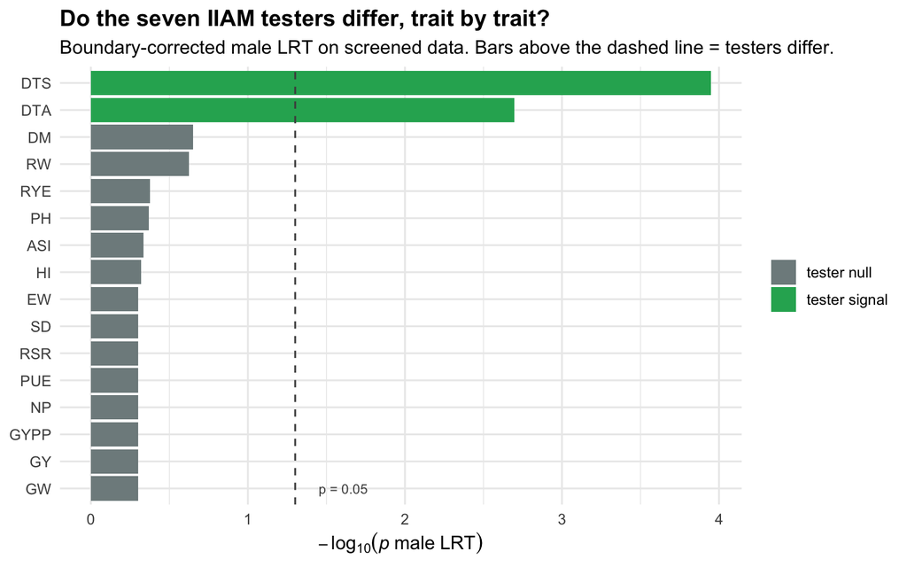

```r
ggplot(results, aes(x = reorder(trait, -p_male), y = -log10(p_male),
                    fill = verdict)) +
  geom_col() +
  geom_hline(yintercept = -log10(0.05), linetype = "dashed", color = "grey30") +
  annotate("text", x = 1, y = -log10(0.05) + 0.15, label = "p = 0.05",
           hjust = 0, size = 3, color = "grey30") +
  coord_flip() +
  scale_fill_manual(values = c("tester null" = "#7f8c8d", "tester signal" = "#27ae60"),
                    name = NULL) +
  labs(
    title    = "Do the seven IIAM testers differ, trait by trait?",
    subtitle = "Boundary-corrected male LRT on screened data. Bars above the dashed line = testers differ.",
    x = NULL, y = expression(-log[10](italic(p)~male~LRT))
  ) +
  theme_minimal(base_size = 12) +
  theme(plot.title = element_text(face = "bold"))
```

# 6 Heritability per trait

The same line × tester model already carries every variance component needed for **entry-mean (cross-mean) heritability** — the accuracy with which cross rankings can be selected on their mean across environments and replicates, and the most useful heritability for multi-environment breeding decisions. Because the female (CIMMYT lines) and male (IIAM testers) sets come from **distinct gene pools**, the among-cross genetic variance partitions into an additive (GCA) and a dominance (SCA) part (Isik et al. 2017; the full derivation is worked in `gca_calculation.html`). With $e$ environments and $r$ reps per environment:

- **Genetic variance of cross means:** $\sigma^2_G = \sigma^2_{\text{female}} + \sigma^2_{\text{male}} + \sigma^2_{\text{cross}}$
- **Additive component (entry-mean):** $\sigma^2_{A,\bar{x}} = \sigma^2_{\text{female}} + \sigma^2_{\text{male}}$
- **Dominance component (entry-mean):** $\sigma^2_{D,\bar{x}} = \sigma^2_{\text{cross}}$
- **Total G × E:** $\sigma^2_{GE} = \sigma^2_{\text{female:env}} + \sigma^2_{\text{male:env}} + \sigma^2_{\text{cross:env}}$
- **Entry-mean phenotypic variance:** $\sigma^2_{P,\bar{x}} = \sigma^2_G + \dfrac{\sigma^2_{GE}}{e} + \dfrac{\sigma^2_{\text{res}}}{e\,r}$
- **Narrow-sense heritability:** $h^2_{\bar{x}} = \sigma^2_{A,\bar{x}} / \sigma^2_{P,\bar{x}}$
- **Broad-sense heritability:** $H^2_{\bar{x}} = \sigma^2_G / \sigma^2_{P,\bar{x}}$

Both are bounded in $[0, 1]$, the correct behaviour for a properly specified entry-mean form. The spatial terms (`env:rep`, `env:rep:row`, `env:rep:col`) are nuisance design effects, not part of the genetic or phenotypic partition, so they do not enter these formulas. Variance components are taken from the **same screened fits** as the sweep above, so each trait’s heritability is on its own analysis set.

## 6.1 Why the dominance component is $\sigma^2_{\text{cross}}$

Each hybrid’s genetic value is decomposed by the model into the two parents’ general combining abilities plus a specific-combination deviation:

$$g_{\text{cross}} = \underbrace{\text{GCA}_{\text{female}}}_{(1\,\mid\,\text{female})}
+ \underbrace{\text{GCA}_{\text{male}}}_{(1\,\mid\,\text{male})}
+ \underbrace{\text{SCA}_{\text{female}\times\text{male}}}_{(1\,\mid\,\text{cross})}.$$

The `cross` term (the `female × male` combination) is the **specific combining ability (SCA)** — by construction the deviation of a hybrid from what its parents’ GCAs predict. GCA carries the **additive**, transmissible part of the genetic value; SCA carries what is left over, the **non-additive** part (dominance, plus any epistasis). Taking the variance of the three independent terms gives the among-cross genetic variance and its partition:

$$\sigma^2_G = \operatorname{Var}(g_{\text{cross}})
= \underbrace{\sigma^2_{\text{female}} + \sigma^2_{\text{male}}}_{\sigma^2_{A,\bar{x}}\;(\text{additive, GCA})}
+ \underbrace{\sigma^2_{\text{cross}}}_{\sigma^2_{D,\bar{x}}\;(\text{dominance, SCA})}.$$

So the dominance entry-mean component is **literally the variance of the SCA effects**, $\sigma^2_{D,\bar{x}} = \sigma^2_{\text{cross}}$.

**Why no factor of 4 here.** The relation $\sigma^2_D = 4\,\sigma^2_{\text{SCA}}$ (and $\sigma^2_A = 2(\sigma^2_{\text{female}} + \sigma^2_{\text{male}})$) reconstructs the *individual-organism* variances on the underlying plot scale, because SCA variance among full-sib families equals only $\tfrac14\sigma^2_D$:

$$\sigma^2_{A,\text{ind}} = 2(\sigma^2_{\text{female}} + \sigma^2_{\text{male}}),
\qquad \sigma^2_{D,\text{ind}} = 4\,\sigma^2_{\text{cross}}.$$

The **entry-mean** heritability here is not after individual $V_A$/$V_D$ — it partitions the variance of the **cross means** that selection actually acts on. On that scale the components enter *directly, unscaled*; applying the factor-4 would mix the two scales and can drive $H^2 > 1$.

**A label caveat.** $\sigma^2_{\text{cross}}$ absorbs **all** non-additive genetic variance — dominance *and* epistasis — so “dominance” is conventional shorthand; more precisely it is the non-additive (SCA) variance. That is exactly why $H^2$, which includes $\sigma^2_{\text{cross}}$, is *broad*-sense, while $h^2$, which uses only the GCA terms, is *narrow*-sense.

```r
herit <- results %>%
  mutate(
    sigma2_G  = sigma2_female + sigma2_male + sigma2_cross,  # genetic var of cross means
    sigma2_A  = sigma2_female + sigma2_male,                 # additive (GCA) part
    sigma2_GE = sigma2_fxe + sigma2_mxe + sigma2_cxe,        # total G×E
    Vp_mean   = sigma2_G + sigma2_GE / n_env + sigma2_resid / (n_env * n_rep),
    h2_narrow = if_else(Vp_mean > 0, sigma2_A / Vp_mean, NA_real_),
    H2_broad  = if_else(Vp_mean > 0, sigma2_G / Vp_mean, NA_real_)
  ) %>%
  arrange(desc(H2_broad))

herit_display <- herit %>%
  transmute(
    Trait         = trait,
    Unit          = unit,
    `σ²_G`        = round(sigma2_G, 4),
    `σ²_GxE`      = round(sigma2_GE, 4),
    `σ²_resid`    = round(sigma2_resid, 4),
    e             = n_env,
    r             = round(n_rep, 1),
    `h² (narrow)` = round(h2_narrow, 3),
    `H² (broad)`  = round(H2_broad, 3)
  )

kable(herit_display,
      caption = "Entry-mean heritability per trait from the line × tester model (screened data), sorted by broad-sense H². σ²_G is the among-cross genetic variance (female + male + cross); h² counts only the additive GCA part (female + male). e = environments, r = mean reps per cross per environment. Grain yield (bold) is the anchor.") %>%
  kable_styling(bootstrap_options = c("striped", "hover", "condensed")) %>%
  row_spec(which(herit$trait == "GY"), bold = TRUE)
```

Entry-mean heritability per trait from the line × tester model (screened data), sorted by broad-sense H². σ²_G is the among-cross genetic variance (female + male + cross); h² counts only the additive GCA part (female + male). e = environments, r = mean reps per cross per environment. Grain yield (bold) is the anchor.

| Trait | Unit | σ²_G | σ²_GxE | σ²_resid | e | r | h² (narrow) | H² (broad) |
| --- | --- | --- | --- | --- | --- | --- | --- | --- |
| SD | cm | 0.0242 | 0.0009 | 0.0533 | 5 | 3 | 0.358 | 0.866 |
| DTA | days | 0.7591 | 0.1704 | 5.8121 | 5 | 3 | 0.578 | 0.642 |
| DTS | days | 0.7836 | 0.2978 | 6.2369 | 5 | 3 | 0.588 | 0.622 |
| RW | g/plot | 9.4043 | 0.0000 | 125.1938 | 5 | 3 | 0.187 | 0.530 |
| PH | cm | 20.0667 | 34.9464 | 256.1888 | 5 | 3 | 0.191 | 0.454 |
| DM | g/plot | 208.5633 | 419.9018 | 2906.8029 | 5 | 3 | 0.143 | 0.429 |
| NP | count | 0.6277 | 0.6105 | 12.1911 | 5 | 3 | 0.336 | 0.401 |
| GY | t/ha | 0.1169 | 0.1554 | 2.2460 | 5 | 3 | 0.122 | 0.393 |
| GYPP | g | 41.0713 | 54.6076 | 789.7720 | 5 | 3 | 0.122 | 0.392 |
| HI | g/g | 0.0004 | 0.0000 | 0.0089 | 5 | 3 | 0.085 | 0.379 |
| GW | g/plot | 14330.4910 | 53183.5495 | 274833.3726 | 5 | 3 | 0.112 | 0.331 |
| RYE | g/g | 0.1642 | 0.0000 | 4.9800 | 5 | 3 | 0.075 | 0.331 |
| EW | g/plot | 12173.1607 | 61133.1990 | 365173.4091 | 5 | 3 | 0.106 | 0.250 |
| PUE | g/g | 250.7938 | 1537.3115 | 10312.2058 | 5 | 3 | 0.000 | 0.201 |
| ASI | days | 0.0194 | 0.0378 | 2.3353 | 5 | 3 | 0.008 | 0.106 |
| RSR | g/g | 0.0000 | 0.0000 | 0.0015 | 5 | 3 | 0.066 | 0.076 |

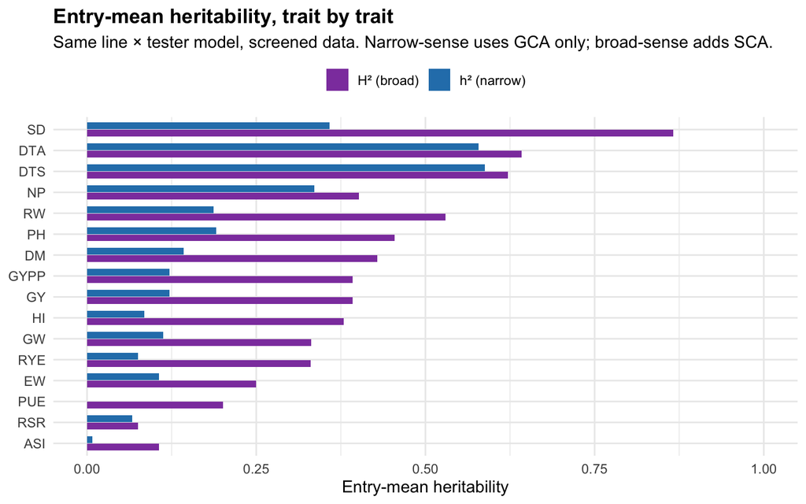

```r
herit %>%
  transmute(trait, `h² (narrow)` = h2_narrow, `H² (broad)` = H2_broad) %>%
  pivot_longer(-trait, names_to = "kind", values_to = "value") %>%
  ggplot(aes(x = reorder(trait, value), y = value, fill = kind)) +
  geom_col(position = position_dodge(width = 0.7), width = 0.65) +
  coord_flip(ylim = c(0, 1)) +
  scale_fill_manual(values = c("h² (narrow)" = "#2980b9", "H² (broad)" = "#8e44ad"),
                    name = NULL) +
  labs(
    title    = "Entry-mean heritability, trait by trait",
    subtitle = "Same line × tester model, screened data. Narrow-sense uses GCA only; broad-sense adds SCA.",
    x = NULL, y = "Entry-mean heritability"
  ) +
  theme_minimal(base_size = 12) +
  theme(plot.title = element_text(face = "bold"),
        legend.position = "top")
```

**Reading.** The gap between $H^2$ (broad) and $h^2$ (narrow) is the SCA (dominance) contribution; where the two bars are close, the cross-mean signal is almost all additive GCA and so transmits reliably to the next generation. A trait can be highly heritable here yet still male-null in the sweep above — $H^2$ pools the **female** GCA, SCA and the male GCA, so it stays high on female differences alone even when the seven testers are interchangeable ($\sigma^2_{\text{male}} \approx 0$). The two tables answer different questions: the sweep asks *do the testers differ?*, while this one asks *how repeatable is a cross mean?*